# Chapter 2: Background

Guido Biele

13.02.2024

## What is conditional probability?

### Unconditional or marginal probability

Let us say you want to know if a random day in the year is a winter day, is a snow day, and what the relationship between winter and snow days is.

We start by drawing a circle, which symbolizes all days in a year:

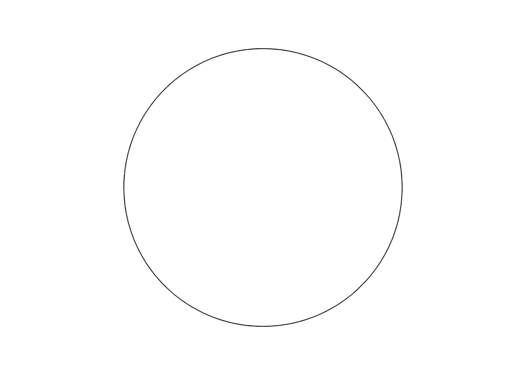

This circle captures all 4 possible day types: winter days with and without snow and days in the other seasons with and without snow. The probability that a day belongs to any of these day types is 1. Therefore, we say that the area of the circle is also 1.

We know that a quarter of the days in a year are in winter months. We visualize this by highlighting a section of the circle in icy blue.

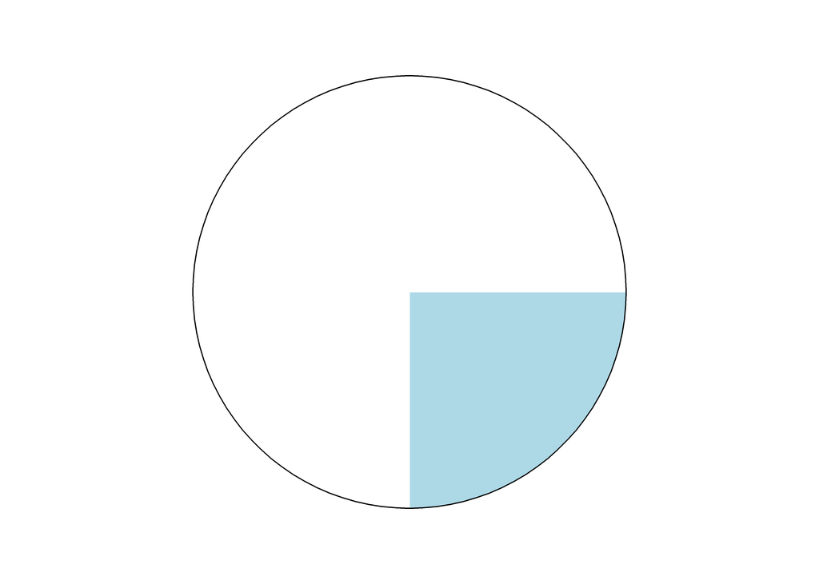

From this we can see that the probability of winter is 1/4, or 0.25. This is an unconditional (or marginal) probability, and we can write $P(winter)$ = 0.25.

Snowy days are usually in winter. Therefore, we draw an ellipse for snow days that largely overlaps with the quadrant for winter days.

The **complement rule** (or subtraction rule) for probabilities says that given the probability of an event $P(A)$ (snow) the probability that this event is not happening is $1-P(A)$. $P(\textrm{not}A) = 1-P(A).$

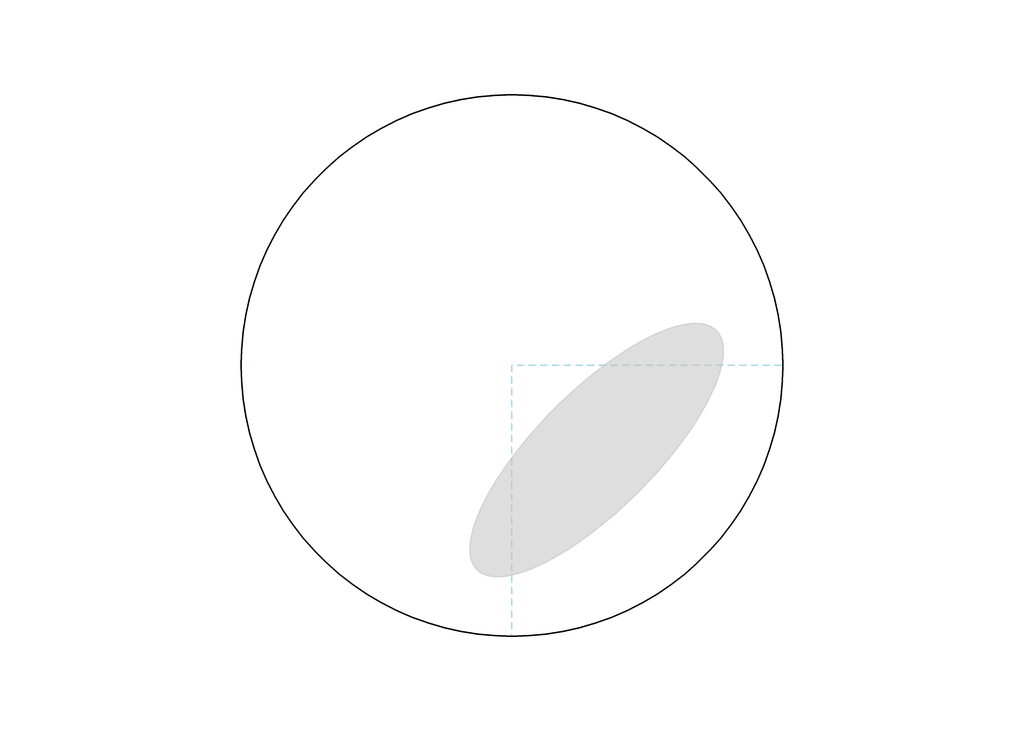

The unconditional (or marginal) probability of snow, $P(snow)$, is the probability of snow independent if it is winter or not, and corresponds to the area of the grey ellipse: $P(snow) =$ 0.14.

### Joint probability

The **joint probability** of winter **and** snow $P(winter, snow)$ or $P(winter \textrm{ and } snow)$ is the ellipse-area that overlaps with the bottom right quadrant, which is shown in the next figure.

The **addition rule** for probabilities says that the probability that *either* of two events $P(A)$ (winter) or $P(B)$ (snow) happens is the the sum of the marginal probabilities $P(A) + P(B)$ minus the **joint probability** (snowy winter days). $P(A \textrm{ or } B) = P(A)+P(B)-P(A \textrm{ and } B)$.  
This is often written as $P(A \cup B) = P(A)+P(B)-P(A \cap B)$, where $\cup$ stands for *union* (or) and $\cap$ stands for the *intersection* (and).

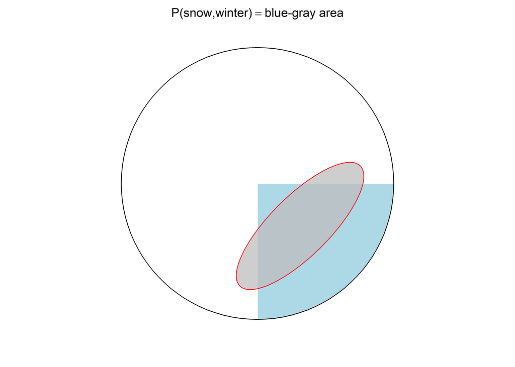

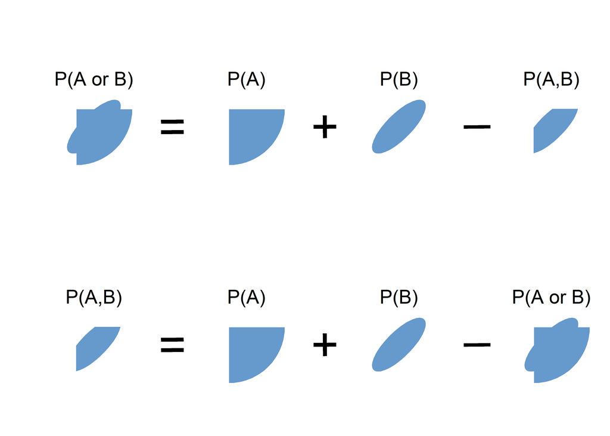

```r
par(mfrow = c(2,4), mar = c(0,0,0,0), oma =c(0,0,0,0), bg = adjustcolor("white",alpha = 0))

pie(c(3,1), labels = "", border = "white", col = c("white","#6699cc"))
draw_ellipse(col = "#6699cc", border = "#6699cc")
text(.25,.25,"P(A or B)",pos = 3, cex = 2)


pie(c(3,1), labels = "", border = "white", col = c("white","#6699cc"))
text(.25,.25,"P(A)",pos = 3, cex = 2)
text(x = -.8,-.25,"=", adj = .5, cex = 5, srt = .5, xpd = FALSE)

pie(c(3,1), col = "white", labels = "", border = "white")
draw_ellipse(col = "#6699cc", border = "#6699cc")
text(.25,.25,"P(B)",pos = 3, cex = 2)
text(x = -.8,-.25,"+", adj = .5, cex = 5, srt = .5, xpd = FALSE)


pie(c(3,1), col = "white", labels = "", border = "white")
draw_ellipse(col = "#6699cc", border = "#6699cc")
rect(0,0,.7,.2, col = "white", border = NA)
rect(0,0,-.2,-.7, col = "white", border = NA)
text(.25,.25,"P(A,B)",pos = 3, cex = 2)
text(x = -.8,-.25,"–", adj = .5, cex = 5, srt = .5, xpd = FALSE)


pie(c(3,1), col = "white", labels = "", border = "white")
draw_ellipse(col = "#6699cc", border = "#6699cc")
rect(0,0,.7,.2, col = "white", border = NA)
rect(0,0,-.2,-.7, col = "white", border = NA)
text(.25,.25,"P(A,B)",pos = 3, cex = 2)

pie(c(3,1), labels = "", border = "white", col = c("white","#6699cc"))
text(.25,.25,"P(A)",pos = 3, cex = 2)
text(x = -.8,-.25,"=", adj = .5, cex = 5, srt = .5, xpd = FALSE)

pie(c(3,1), col = "white", labels = "", border = "white")
draw_ellipse(col = "#6699cc", border = "#6699cc")
text(.25,.25,"P(B)",pos = 3, cex = 2)
text(x = -.8,-.25,"+", adj = .5, cex = 5, srt = .5, xpd = FALSE)

pie(c(3,1), labels = "", border = "white", col = c("white","#6699cc"))
draw_ellipse(col = "#6699cc", border = "#6699cc")
text(.25,.25,"P(A or B)",pos = 3, cex = 2)
text(x = -.8,-.25,"–", adj = .5, cex = 5, srt = .5, xpd = FALSE)
```

### Conditional probability

A conditional probability gives the answer to the question “Given that it is winter, what is the probability of snow”. This amounts to the question “What is the size of the ellipse-area that overlaps with the bottom right quadrant, *relative to* the area of the bottom right quadrant”. The next figure visualizes this.

This is an application of the **product rule**.  
If we have two events $A$ (winter) and $B$ (snow), the **joint probability** of both events $P(A,B)$ is calculated by multiplying the **unconditional probability** $P(A)$ (winter) with the **conditional probability** $P(B|A)$ (the conditional probability of snow given winter). If we rearrange $P(A,B) = P(A) \cdot P(B|A)$ we get $P(B|A) = P(A,B)/P(A)$.

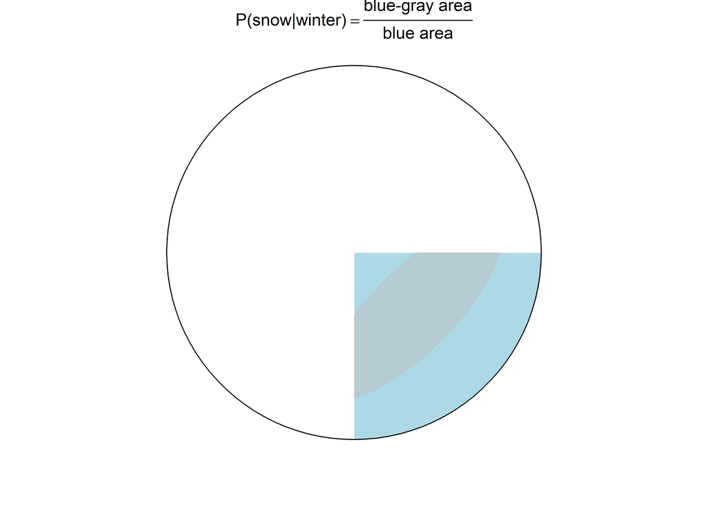

To obtain a conditional probability, we “condition” our question about the probability of snow on the value of another variable, here that the season is winter. In comparison, the joint probability asks “What is the size of the trimmed ellipse-area, *relative to* the total circle area”.

The following figures show fractions that make even clearer hat the joint probability is the probability of snowy winter days divided by the probability of any day (which is just one), and that the conditional probability is the probability of snowy winter days divided by the probability of winter days.

**Joint probability:** $P(A,B) = P(A) \cdot P(B|A)$ or $P(A,B) = P(B) \cdot P(A|B)$  
**Conditional probability:** $P(B|A) = P(A,B)/P(A)$ and $P(A|B) = P(A,B)/P(B)$.

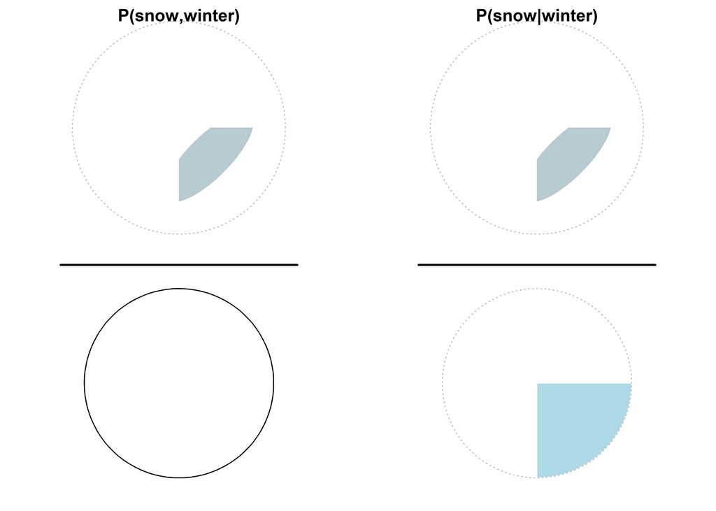

*Because the probability of a winter day is smaller than 1 and dividing by a number smaller than one makes a number larger, dividing by the marginal probability of winter ensures that the conditional probability is larger than the joint probability.* This makes sense, as snow in winter has to be more likely than winter-snow in the whole year.

So, to calculate the conditional probability $P(snow|winter)$ we want to answer the question “What is the size of the ellipse-area that overlaps with the bottom right quadrant, *relative to* the area of the bottom right quadrant”. Unfortunately, there is no simple equation for calculating the overlap of an ellipse and a circle quadrant. But we can approximate the correct answer by randomly placing points into the circle and checking if they are in the bottom right quadrant (winter), in the ellipse (snow), or in the area of the ellipse that overlaps with the bottom right quadrant (winter and snow).

Here is the code for the simulation. You don’t need to understand all of it, the important part is that we are keeping track of winter and snow days in the vectors with the names `is.winter` and `is.snow`, respectively.

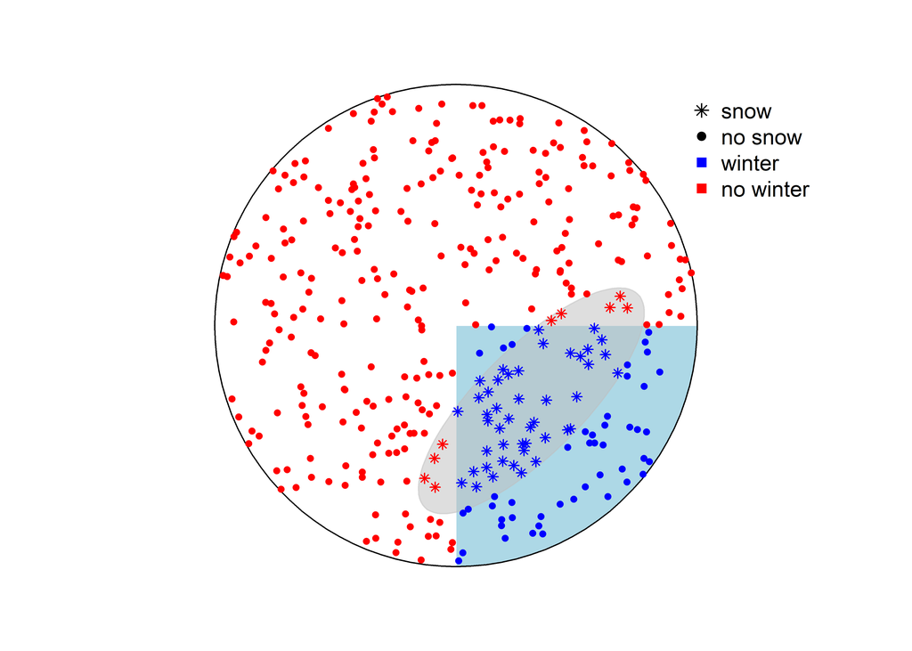

```r
set.seed(123)

# draw the background
draw_pie()
draw_ellipse()

N = 365
is.winter = vector(length = N) # vector to count winter days
is.snow = vector(length = N) # vector to count snow days

for (k in 1:N) {
  # generate random point with custom function
  xy = rpoint_in_circle()

  # check if it is a snow day, i.e. in ellipse, with custom function
  is.snow[k] = in_ellipse(xy,h.e,k.e,a.e,b.e,e.rot)
  # check if it is a winter day
  is.winter[k] = xy[1] > 0 & xy[2] < 0

  # plot points
  points(xy[1],xy[2],
         pch = ifelse(is.snow[k] == T,8,16), cex = .75,
         bg = ifelse(is.winter[k] == T,"blue","red"),
         col = ifelse(is.winter[k] == T,"blue","red"))
}
legend(.75,.8,
       pch = c(8,16,15,15), bty = "n",
       col = c("black","black","blue","red"),
       legend = c("snow","no snow", "winter", "no winter"))
```

Let’s first calculate the probability of winter, which should be around 0.25. This is simply the number of blue dots divided by the total number of dots.

```r
N_winter = sum(is.winter)
P_winter = N_winter/N
P_winter %>% round(2)
```

```
## [1] 0.25
```

Now, the probability of snow (star-shaped dots divided by total number of dots):

```r
N_snow = sum(is.snow)
P_snow = N_snow/N
P_snow %>% round(2)
```

```
## [1] 0.15
```

And now it gets interesting. For the joint probability of winter and snow $P(winter, snow)$ we count the number of blue stars.

```r
# logical indexing:
# is.snow[is.winter] returns only those entries of the
# vector is.snow that are at positions where the
# value for is.winter is TRUE
N_winter_and_snow = sum(is.snow[is.winter])
P_winter_and_snow = N_winter_and_snow/N
P_winter_and_snow %>% round(2)
```

```
## [1] 0.12
```

Check the last code block and see that to get the joint probability we divide by the total number of dots `N`.

In contrast, for conditional probabilities, we want to divide by the number of dots that have the value we are conditioning on. If we want to calculate the conditional probability $P(snow | winter)$, we therefore have to divide by the number of winter dots:

```r
P_snow_given_winter = N_winter_and_snow/N_winter
P_snow_given_winter %>% round(2)
```

```
## [1] 0.48
```

If you check further above, you can see that `P_winter_and_snow` and `P_winter` are respectively calculated by dividing `N_winter_and_snow` and `N_winter` with `N`. Therefore, `N_winter_and_snow/N_winter` and `P_winter_and_snow/P_winter` have the same result and we can also write:

```r
P_snow_given_winter = P_winter_and_snow/P_winter
```

Hopefully, you recognize now that we have the conditional probability on the left side (`P_snow_given_winter` or $P(snow|winter)$), which we calculate with help of the joint probability (`P_winter_and_snow` or $P(snow, winter)$) and the unconditional (marginal) probability (`P_winter` or $P(winter)$) on the right side:

$$\overset{\color{violet}{\text{conditional probability}}}{P(snow|winter)}
= \frac{\overset{\color{red}{\text{joint probability}}}{P(snow,
winter)}}{\overset{\color{blue}{\text{marginal
probability}}}{P(winter)}}$$

or more abstract:

$$\overset{\color{violet}{\text{conditional probability}}}{P(A|B)} =
\frac{\overset{\color{red}{\text{joint probability}}}{P(A,
B)}}{\overset{\color{blue}{\text{marginal probability}}}{P(B)}}$$
and by multiplying with $P(B)$ on both sides, we get first

$$\overset{\color{violet}{\text{conditional probability}}}{P(A|B)} \cdot
\overset{\color{blue}{\text{marginal probability}}}{P(B)} =
\overset{\color{red}{\text{joint probability}}}{P(A,B)}$$

which is the same as

$$\overset{\color{red}{\text{joint probability}}}{P(A,B)} =
\overset{\color{violet}{\text{conditional probability}}}{P(A|B)} \cdot
\overset{\color{blue}{\text{marginal probability}}}{P(B)}$$

This is the general product rule (or chain rule) that connects conditional probabilities with joint probabilities.

## Deriving Bayes rule

Exercise 2E3, which asks which expressions are consistent with “probability of Monday given that it is raining”, can be used to derive Bayes rule.

The correct answers are.

1: P(Monday | rain)

4: P(rain | Monday) * P(Monday) / P(rain)

The question is then if we can show that

$P(Monday|rain) = P(rain|Monday) \cdot P(Monday) / P(rain)$?

The key to the solution is that we can use both $P(Monday|rain)$ and $P(rain|Monday)$ to calculate the same thing: the joint probability of $P(Monday,rain)$.

Page 37 shows the relationship of joint and conditional probability:

$P(A,B) = P(\textrm{conditioned}|\textrm{conditioning}) \cdot P(\textrm{conditioning})$ $P(A,B) = P(\textrm{target}|\textrm{given}) \cdot P(\textrm{given})$

$$P(A,B) = \color{blue}{P(A|B) \cdot P(B)} \\
P(A,B) = \color{red}{P(B|A) \cdot P(A)}$$

Therefore, we can say that the joint probability that it is Monday and raining is

$$P(Monday,rain) =
\color{blue}{P(rain|Monday) \cdot P(Monday)}$$

or

$$P(Monday,rain) =
\color{red}{P(Monday|rain) \cdot P(rain)}$$
and we can further say

$$\color{red}{P(Monday|rain) \cdot P(rain)} = \color{blue}{P(rain|Monday)
\cdot P(Monday)}$$

If we want to know what P(Monday|rain) is, we now have to divide on both sides with P(rain), which gives us

$$\color{red}{P(Monday|rain)} = \frac{\color{blue}{P(rain|Monday) \cdot
P(Monday)}}{\color{red}{P(rain)}}$$

where the right hand side is answer 4 from above.

Maybe the last equation looks familiar. To make it a bit more recognizable, we can replace Monday with $A$ and $rain$ with $B$:

$$P(A|B) = \frac{P(B|A) \cdot P(A)}{P(B)}$$
This is Bayes Rule, which one uses to calculate the inverse conditional probability, i.e. when we have information about the probability of $B$ given $A$ and want to calculate the probability of $A$ given $B$.

## Probability distributions and how do we use them for Bayesian statistics?

### Functions

A probability distribution is a function, that is an object that receives input and gives an output. This is very general, and so we can have functions that return always the same value ($f(x) = 0$), that square a value ($f(x) = x^2$), or that check if a certain condition is met ($f(x) = 1(X == 5)$. [^1]

Probability distributions are a special form of functions. Here are some functions you have probably already encountered.

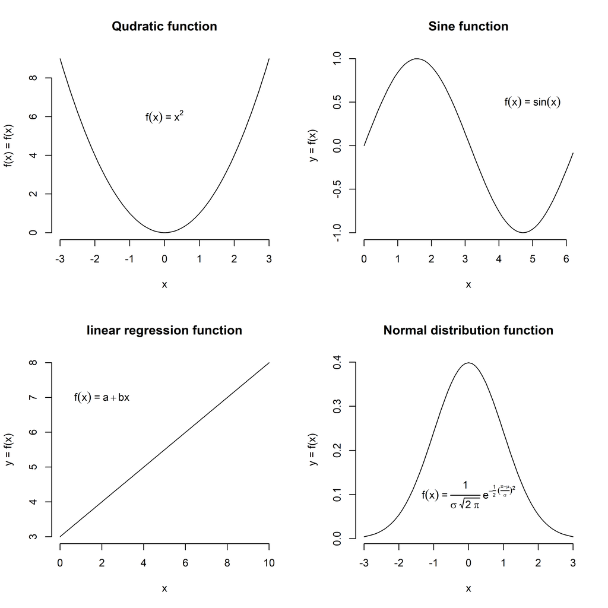

In the context of Bayesian statistics analysis, we use probability distributions to describe a state of the world *including how uncertain we are*.

### Domain of distributions

For such a function, we first need to be explicit what we are uncertain about. Continuing with the globe tossing example, we can say that we are uncertain about if we will catch the globe with the tip of the index finger on water.

If we were sure to land on water, we would say $P(water) = 1$, and if we were sure to land on land, we would say $P(water) = 0$. But because we are uncertain, anything between 0 and 1 is possible. Therefore, our function to describe this uncertainty should allow values between 0 and 1. We can start drawing the function by just specifying an x axis that goes from 0 to 1.

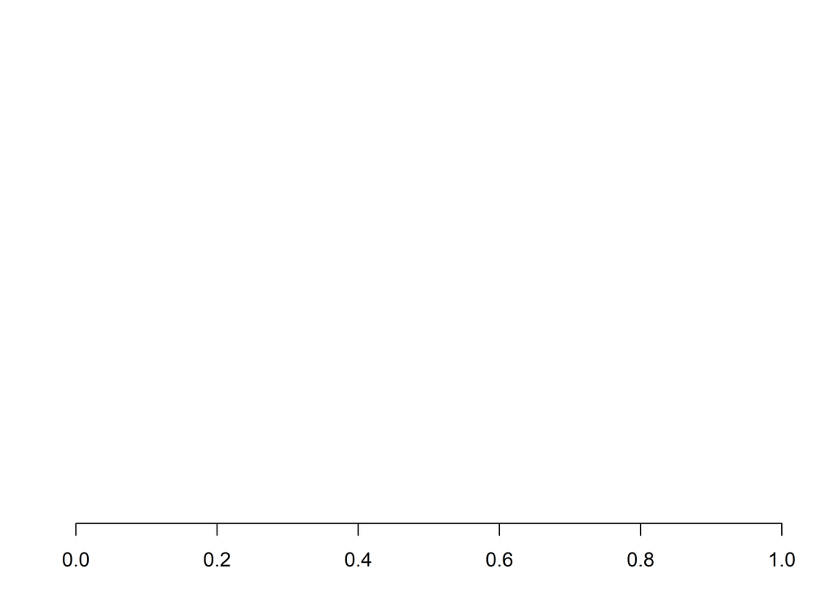

### Probability density

Before we display uncertainty, let’s look at how this function looks if we are certain to land on water:

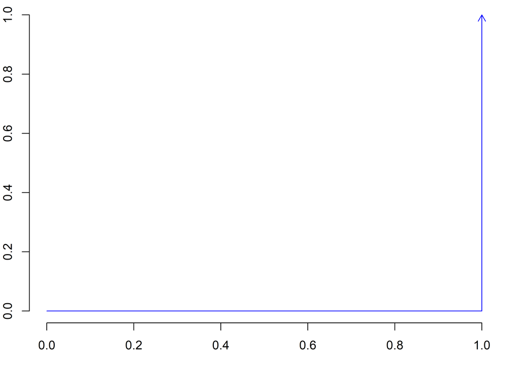

```r
par(mar=c(3,2,0,1))
plot(0,type = "n",
     ylim = c(0,1.01),
     xlim = c(0,1),
     ylab = "", xlab = "p",
     bty = "n")
arrows(1,0,1,1, col = "blue", length = .1)
lines(c(0,1),c(0,0), col = "blue")
```

If we are certain to land on water, $P(water)$ = 1[^2] and all other probabilities have the value zero.

If we want to express uncertainty, we also have to allow for all other values. If we had no information whatsoever to say something about the probability to land on water, all probabilities should get the same value.

**Probability distributions in R** In R, functions that return the density for a given value x for a distribution start with **d**. For instance, `dbeta(x = 0.5, shape1 = 1, shape2 = 1)` returns the density for the value 0.5 under the beta distribution where the parameters shape1 and shape2 have the value 1. `dnorm(x = 0.5, mean = 1, sd = 1)` returns the density for the value 0.5 under the normal distribution with a mean of 1 and a sd of 1.

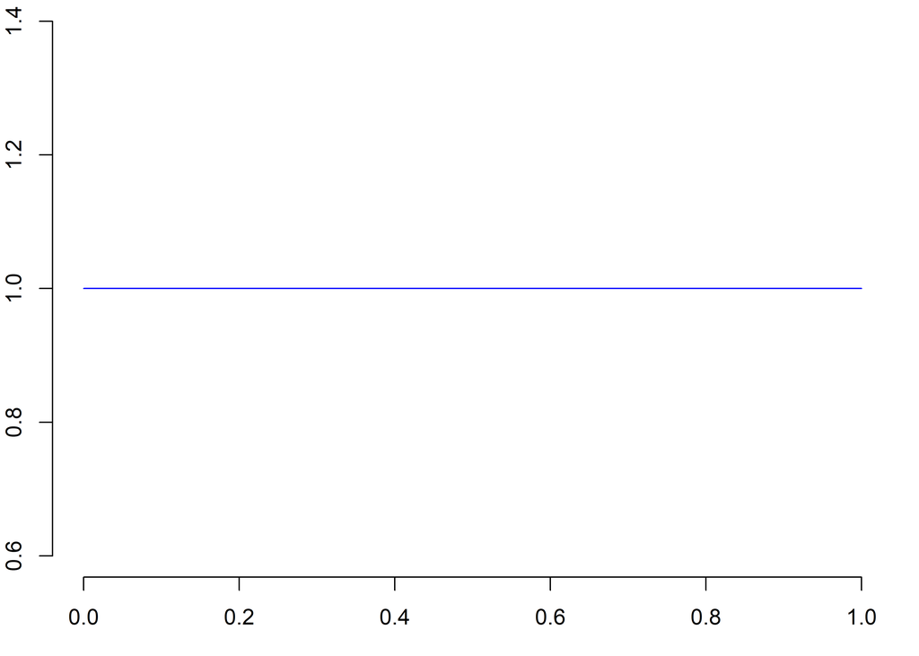

For this function to be a probability distribution, the area under the function (the integral) must sum up to 1.

To see this, we can observe in the next plot that the area under the probability function remains constant while we go from believing weakly (left) to more strongly (right) that the probability to land on water is larger than 0.5.

To generate random samples, we use functions that start with **r**: `rnorm(n = 1000, mean = 1, sd = 1)` returns 1000 random numbers from a normal distribution with the same parameters.

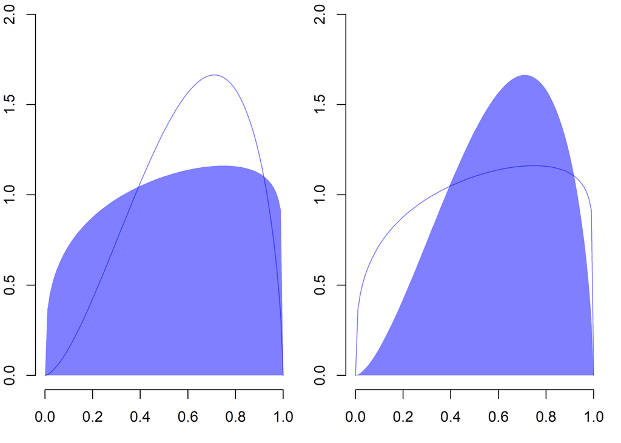

To summarize, one can think of a probability distribution as a function that expresses how likely different values of a parameter (here p) are and whose area under the curve (or integral) is 1.

Depending on the nature of a parameter, different probability distributions must be used. Above, we use the so called beta distribution, because this distribution allows values between 0 and 1, which matches the fact that probabilities need to be between 0 and 1. For other phenomena different distributions can be used. For instance, we might want to use a *normal distribution* to characterize our uncertainty about tomorrow’s temperature. a *Poisson distribution* to characterize uncertainty about things we count, like the number of shoes a person has, or a *binomial distribution* to characterize uncertainty about how success probabilities, like how many students hand in exercises in time.

### Probability distributions in Bayesian Statistics

**Rationality, Bayes rule and prior probability** Bayes’ is the only logical method to update probabilities with new data. Classical Bayesian statistics does not mandate that prior probabilities align with the observable world. Individuals’ perceptions vary, hence prior probabilities are partly subjective beliefs. Interpreting probabilities as long-term frequencies ensures consistency with the observed world, albeit limiting the types of events to which probabilities can be assigned. Modern Bayesian statisticians acknowledge the subjective nature of prior probabilities, but they also advocate for these to be in consistent with empirical evidence.

Let’s walk through a simple example. We start by describing our prior judgement, that we are slightly confident that that index finger touches water rather than land, with a beta distribution:

We use the `dbeta` function for the prior

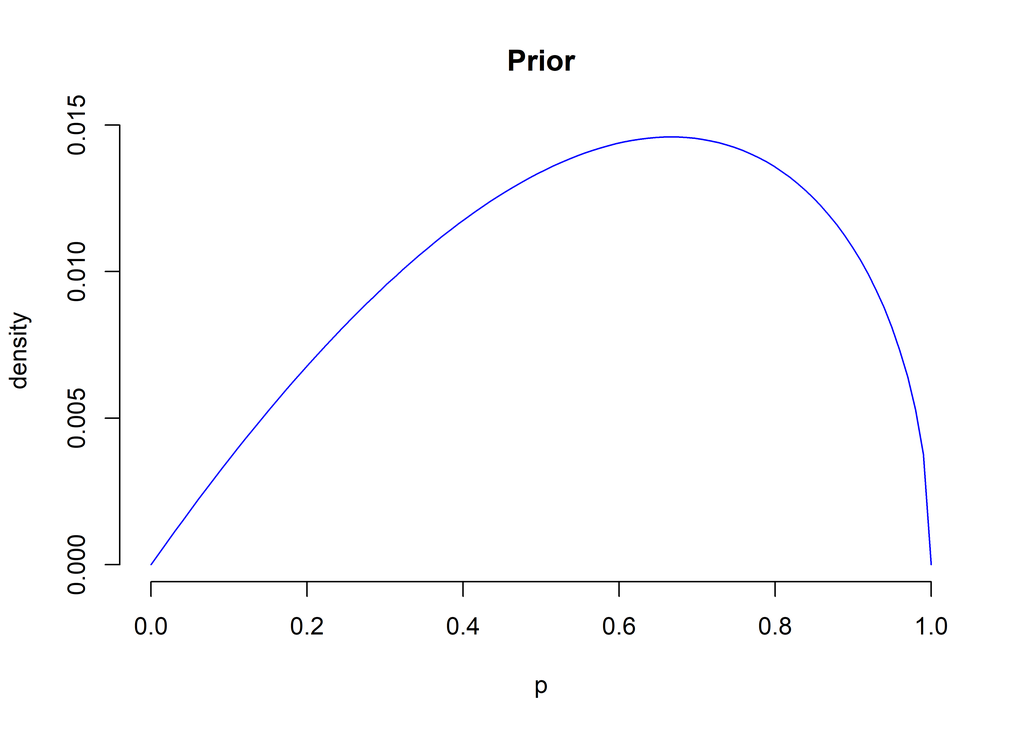

Next the likelihood. For the globe tossing example, we can think of each toss as a trial and of each landing on the index finger as a success. The distribution that gives the likelihood of different success probabilities $p$ given a number of trials and successes is the *binomial distribution*. So we use this distribution to get the likelihood function. Let us assume we had 4 trials and 3 successes.

The likelihood is just the density of the observed data given different parameters values. Because we count successes out of trials, we calculate the likelihood with the `dbinom` function. (`dbinom(x = 3, size = 4, prob = p)`, where `p` is a vector with parameter values.) **type `?dbinom` in the R-Consol to see the documentation of the function.**

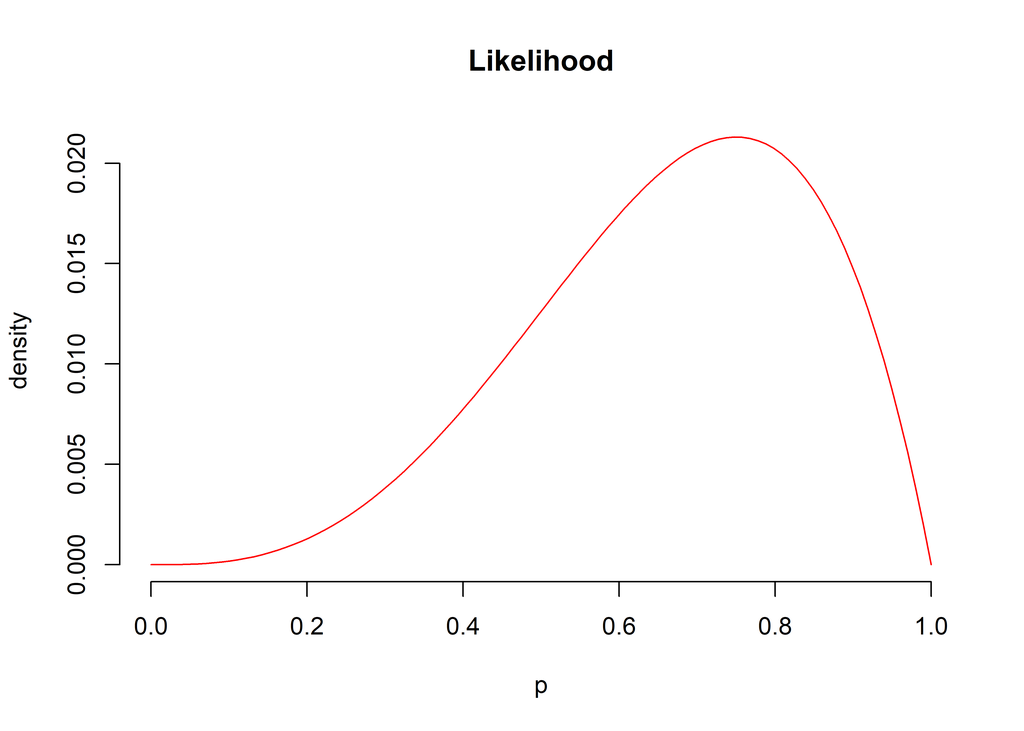

Now Let us re-introduce Bayes rule, which we described above as:

$$P(A|B) = \frac{P(B|A) \cdot P(A)}{P(B)}$$

If we just replace $A$ with $parameter$ and $B$ with $data$ and annotate the different terms we get

$$\overset{\color{violet}{\text{posterior
probability}}}{P(parameter|data)} =
\frac{\overset{\color{red}{\text{likelihood}}}{P(data|parameter)} \cdot
\overset{\color{blue}{\text{prior
probability}}}{P(parameter)}}{\overset{\color{orange}{\text{evidence}}}{P(data)}}$$

This shows us that if we just multiply the likelihood with the prior, two things we just calculated and plotted above, we get something that is proportional to the posterior probability of the parameter (probability to land on water with the index finger on water) given the data. This is what is meant if you see this expression:

$$posterior \propto likelihood \cdot prior$$

Let us just calculate and plot this:

```r
prior_x_likelihood = prior * likelihood
```

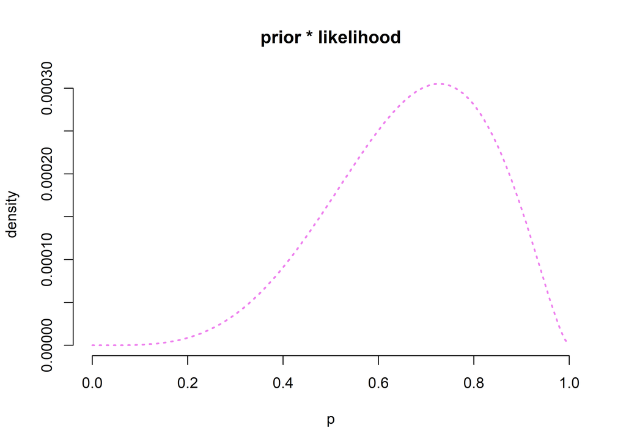

```r
s = sum(prior_x_likelihood)
posterior = prior_x_likelihood/s
c(1/s, sum(posterior))
```

```
## [1] 77.34548  1.00000
```

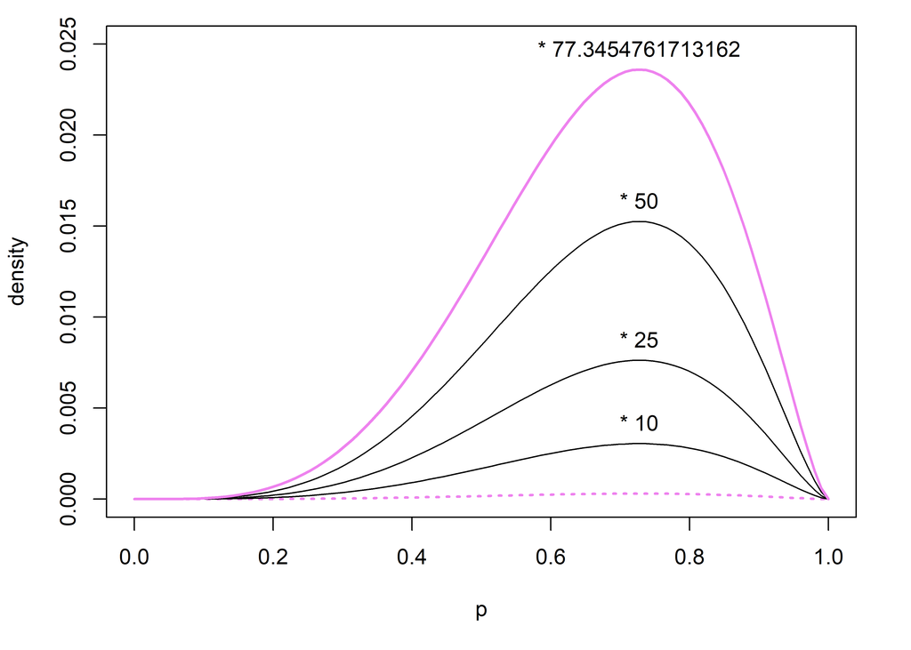

The next plot shows the posterior distribution together with the prior distribution and the likelihood. We are also adding a plot for the un-normalized posterior with a dotted line.

The outcome of Bayesian analysis is a posterior distribution. Typically, we report the mean (or median) of this distribution as a point estimate and use credible intervals to convey uncertainty.

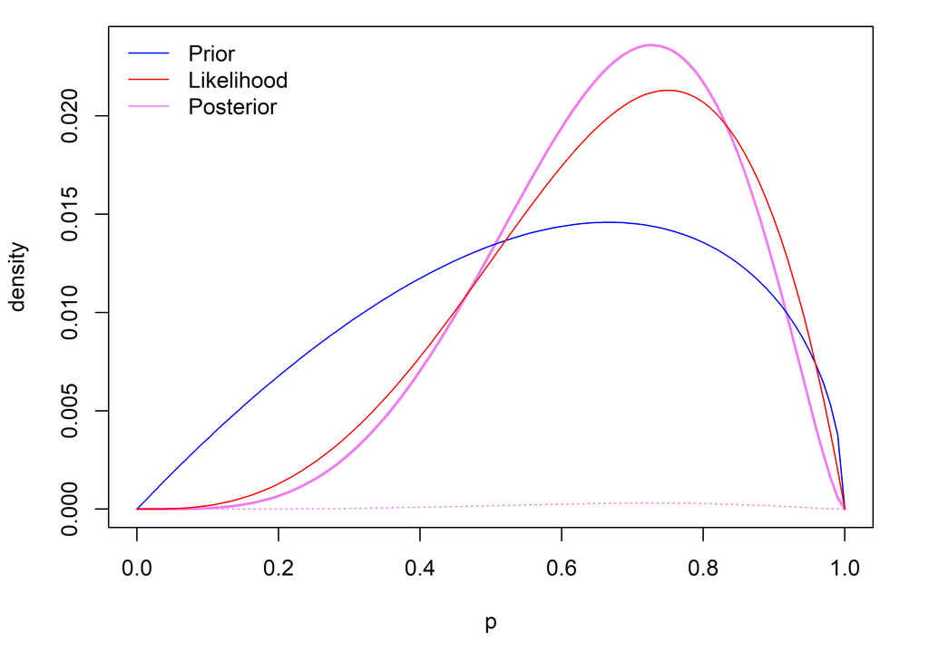

The figure shows that the posterior is a compromise between the prior distribution and the likelihood. That is, it is a compromise between our information before we saw the data and the information that is in the data.

Because we had relatively little data compared to the information in the prior, we can still clearly see the influence of the prior in the posterior. However, if we collect five times the data, we become more certain (the likelihood and the posterior distribution are narrower) and the influence of the prior is diminished so that the posterior will be very similar to the likelihood:

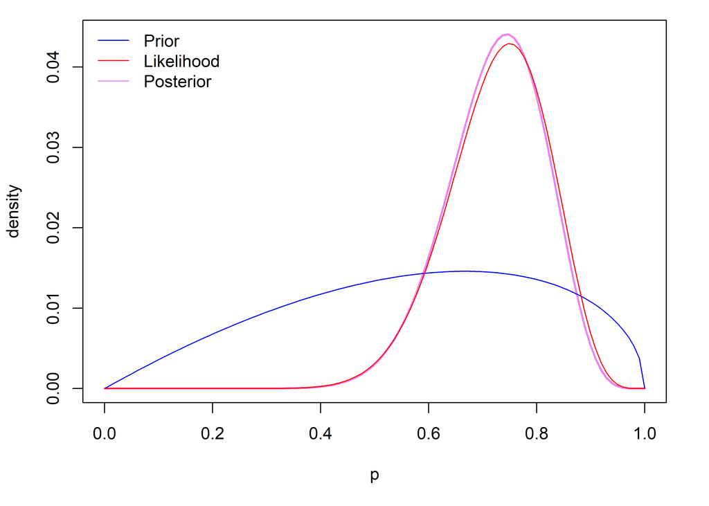

So it is not so easy to “cheat” with priors to get what one wants, provided one has collected sufficient data of course.

# Grid search

First we defined a grid and plot a the prior probability values:

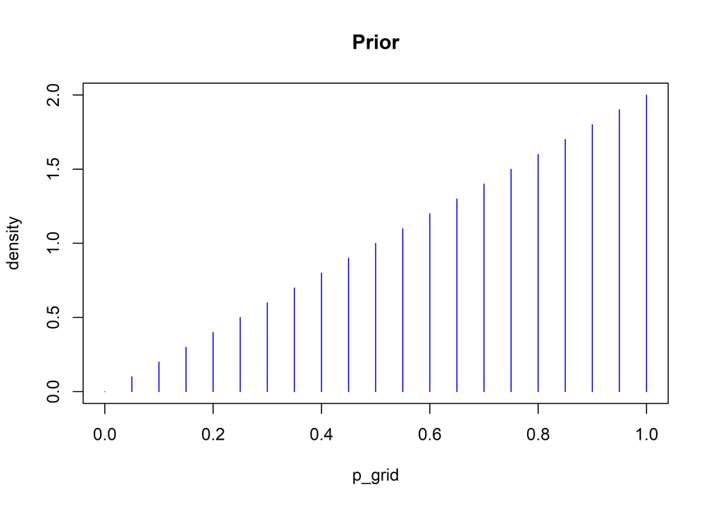

```r
p_grid = seq(0,1,by = .05)
prior = dbeta(p_grid,2,1)
plot(p_grid, prior, type = "h", col = "blue",
     ylab = "density", main = "Prior")
```

Vertical lines indicate the prior plausibility for parameter values in the grid.

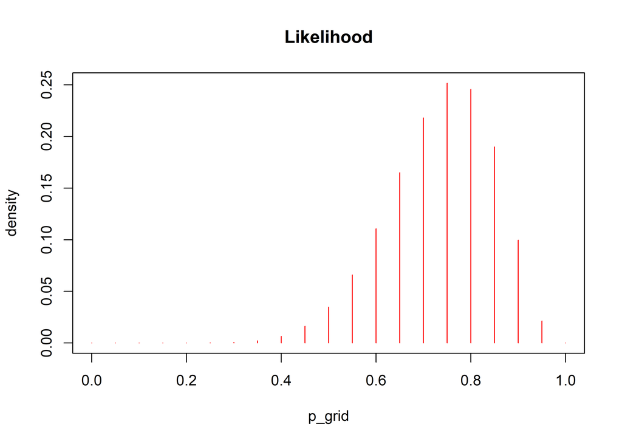

```r
likelihood = dbinom(10,13,p_grid)
plot(p_grid, likelihood, type = "h", col = "red",
     ylab = "density", main = "Likelihood")
```

Vertical lines indicate the plausibility of the data for the parameter values in the grid.

And now we can calculate the un-normalized posterior as a product of prior and likelihood:

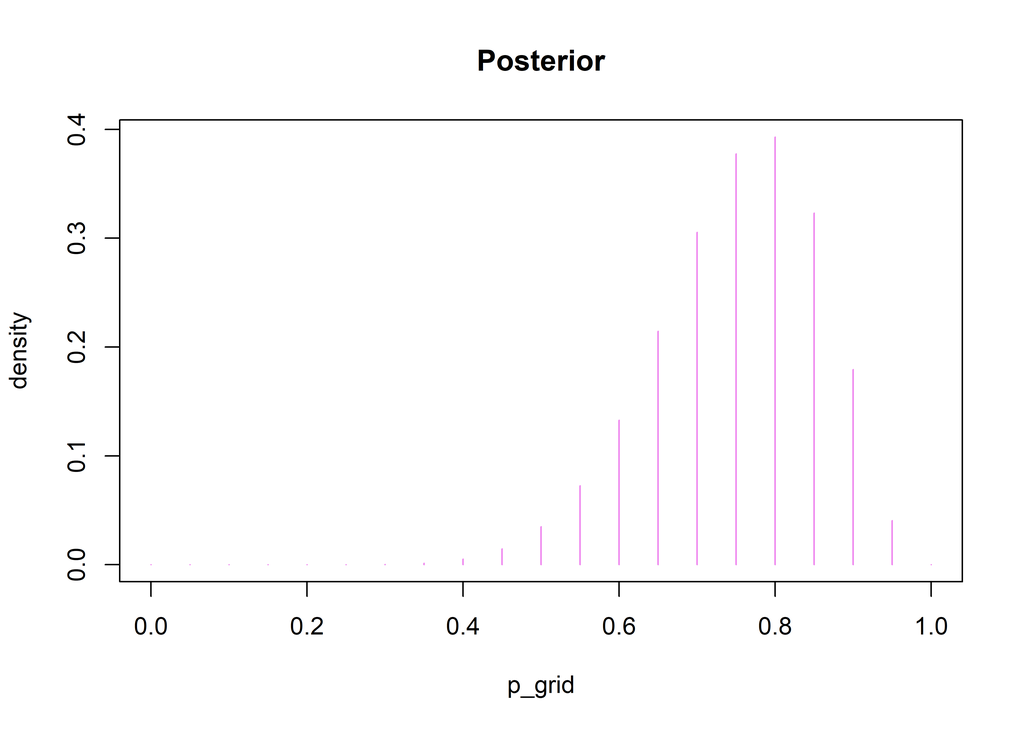

```r
posterior = prior * likelihood
plot(p_grid, posterior, type = "h", col = "violet",
     ylab = "density", main = "Posterior")
```

Vertical lines indicate the posterior plausibility of the parameter values in the grid, given the data and the prior.

Here is a plot with all three together:

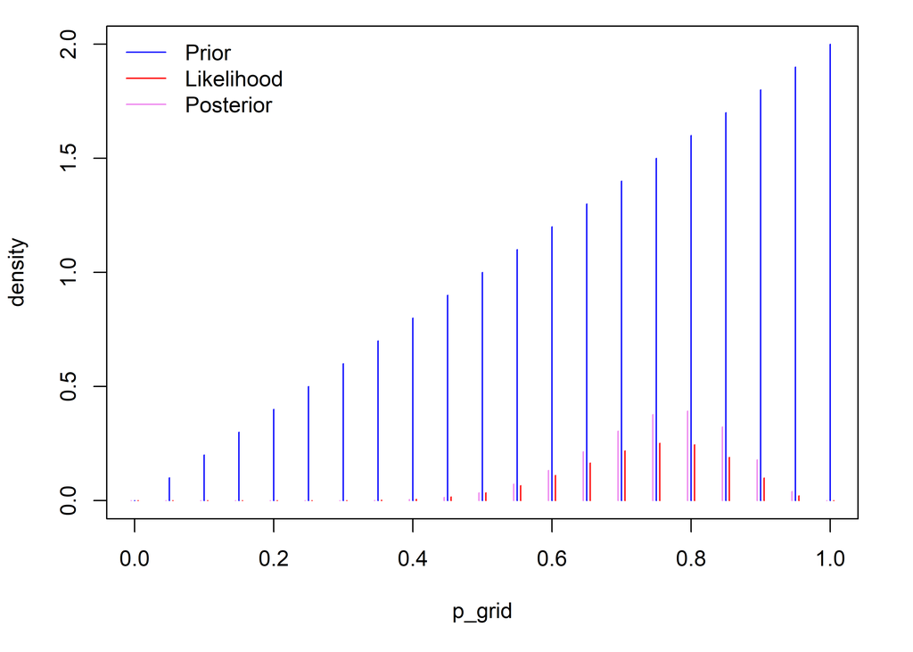

```r
par(mar = c(5.1,4.1,1,2.1))
ylim = c(0,max(c(likelihood,posterior,prior)))
plot(p_grid, prior, type = "h",col = "blue",
     ylab = "density", ylim = ylim)
lines(p_grid+.005, likelihood, type = "h", col = "red")
lines(p_grid-.005, posterior, type = "h", col = "violet")
legend("topleft",col = c("blue","red","violet"),
       lty = 1, legend = c("Prior","Likelihood","Posterior"),
       bty = "n")
```

We can make the plot easier to view by normalizing all values so that they sum up to 1 for prior, likelihood and posterior. In each distribution, only the relative values at the different points of the grid are relevant!

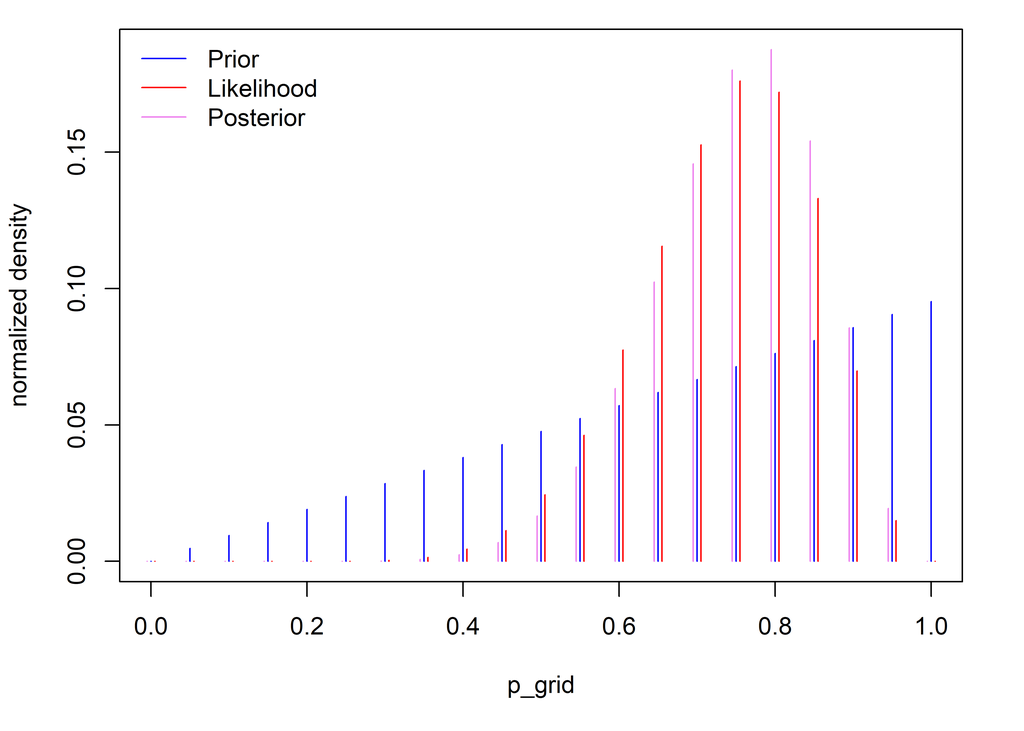

```r
n_prior = prior/sum(prior)
n_likelihood = likelihood/sum(likelihood)
n_posterior = posterior/sum(posterior)
n_ylim = c(0,max(c(n_likelihood,n_posterior,n_prior)))
par(mar = c(5.1,4.1,1,2.1))
plot(p_grid, n_prior, type = "h", col = "blue",
     ylab = "normalized density", ylim = n_ylim)
lines(p_grid+.005, n_likelihood, type = "h", col = "red")
lines(p_grid-.005, n_posterior, type = "h", col = "violet")
legend("topleft",col = c("blue","red","violet"),
       lty = 1, legend = c("Prior","Likelihood","Posterior"),
       bty = "n")
```

This plot helps to understand that for a grid search we take each point of the grid and:

- determine the prior probability (we used a beta distribution)
- calculate the likelihood, i.e. the conditional probability of the data (we used the binomial distribution)
- calculate the posterior by multiplying the prior and the likelihood.

However, usually one would not show distributions with vertical lines. Instead, one just shows their outlines:

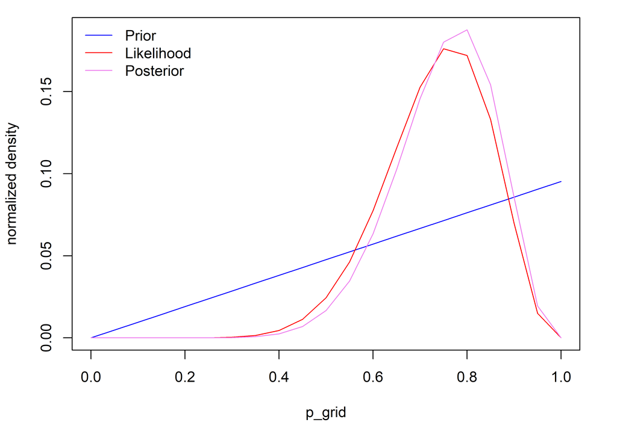

```r
par(mar = c(5.1,4.1,1,2.1))
plot(p_grid, n_prior, col = "blue", type = "l",
     ylab = "normalized density", ylim = n_ylim)
lines(p_grid, n_likelihood, col = "red")
lines(p_grid, n_posterior, col = "violet")
legend("topleft",col = c("blue","red","violet"),
       lty = 1, legend = c("Prior","Likelihood","Posterior"),
       bty = "n")
```

This distribution is not very smooth. We can simply make it smoother by increasing the gridsize:

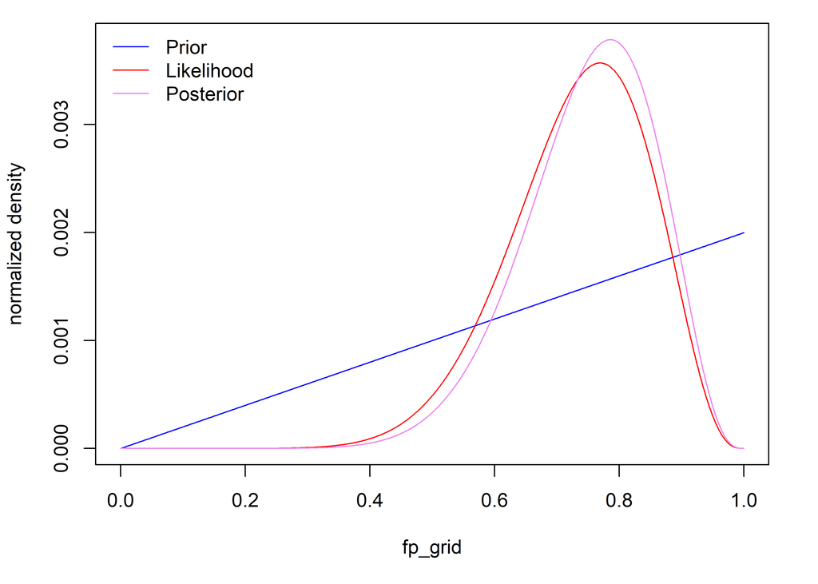

```r
fp_grid = seq(0,1,by = .001)
f_prior = dbeta(fp_grid,2,1)
f_likelihood = dbinom(10,13,fp_grid)
f_posterior = f_prior * f_likelihood

f_prior = f_prior/sum(f_prior)
f_posterior = f_posterior/sum(f_posterior)
f_likelihood = f_likelihood/sum(f_likelihood)
f_ylim = c(0,max(c(f_likelihood,f_posterior,f_prior)))

par(mar = c(5.1,4.1,1,2.1))
plot(fp_grid, f_prior, type = "l", col = "blue",
     ylab = "normalized density", ylim = f_ylim)
lines(fp_grid, f_likelihood, col = "red")
lines(fp_grid, f_posterior, col = "violet")
legend("topleft",col = c("blue","red","violet"),
       lty = 1, legend = c("Prior","Likelihood","Posterior"),
       bty = "n")
```

This exaple shows that we can use grid search to *approximate* the mode of the posterior probability. We only approximate it, because how close we get to the mode depends on how fine our grid is. Because the size of the grid grows exponentially with the number of parameters, it is rarely used in practice. However, it is a straight forward way to find *relatively* good paramter values that is usefull to build an understanding of what we are trying to do if when we fit parameters.

[^1]: Text due to Tomás Varnet, who suggested to also explain what a function is.
[^2]: The figure shows density, not probability
[^3]: Parameters are variables that describe characteristics of distributions, like for example the mean and standard deviation of the normal distribution